# Assignment 1: First Visualization

Sabina Sloman

1/23/2020

# Import the data

These data were originally saved as a Python [`pandas`](https://pandas.pydata.org/) object, so I first converted them to a [`feather`](https://github.com/wesm/feather) format, suggested [here](https://stackoverflow.com/questions/46390461#46434642) as the best way to transfer data between Python and R.

```r
dem.dat <- read_feather("dem_dat.feather")
repub.dat <- read_feather("repub_dat.feather")
```

# Transform the data

Each of the data frames has three columns: `speaker` (the ID of the speaker), `date` (the date on which the speech was said) and `speech` (the text of the speech). What I want is to break the `speech` column up into a bunch of columns, each of which corresponds to the frequency count of a single word.

```r
# Some of this was taken from the StackOverflow exchange
# https://stackoverflow.com/questions/18101047

# I set a lower bound for number of times a word has been seen, which keeps the
# size of the dataset manageable
min.obs <- 500

dtm.dem <- dem.dat$speech %>%
  VectorSource() %>%
  Corpus() %>%
  DocumentTermMatrix(control = list(bounds = list(global = c(min.obs, Inf)),
                                    stopwords = TRUE)) %>%
  as.matrix() %>%
  as_tibble()

dem.dat <- bind_cols(dem.dat, dtm.dem)

dtm.repub <- repub.dat$speech %>%
  VectorSource() %>%
  Corpus() %>%
  DocumentTermMatrix(control = list(bounds = list(global = c(min.obs, Inf)),
                                    stopwords = TRUE)) %>%
  as.matrix() %>%
  as_tibble()

repub.dat <- bind_cols(repub.dat, dtm.repub)

dem.dat$party <- "D"
repub.dat$party <- "R"
dat <- bind_rows(dem.dat, repub.dat) %>%
  # https://stackoverflow.com/questions/47060014#47060112
  mutate_all(~ replace(., is.na(.), 0)) %>%
  mutate(speaker = factor(speaker), date = as.Date(date))
```

Now I have a data frame with 308041 total speeches, given by 462 speakers on 145 different days. Overall, they said 681 unique words more than 500 times.

# Visualization

To get an initial sense of what the overall distribution of words is, I’ll first just create a word cloud.

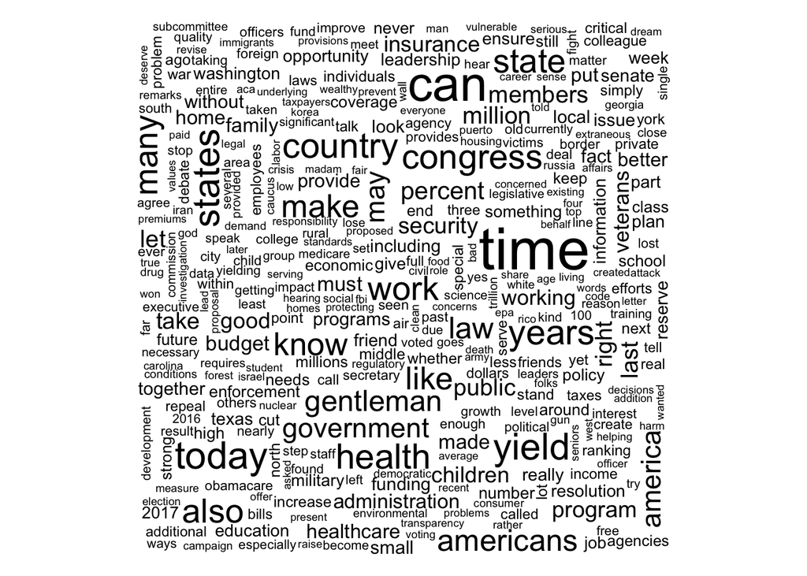

```r
word.dat <- dat %>%
  select(-c("speaker","date","speech","party"))

word.counts <- apply(word.dat, 2, sum)

wordcloud(colnames(word.dat), word.counts)
```

It looks like the word “health” was said a lot. Now I’ll look at how the use of that word changed over the year.

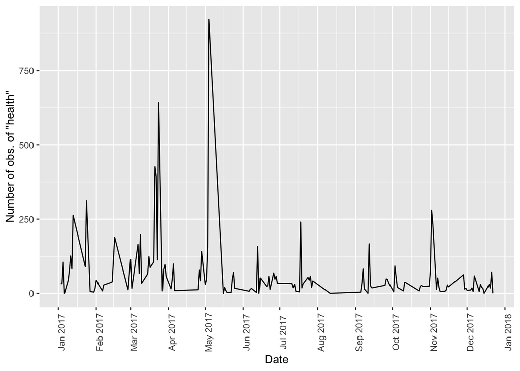

```r
ggplot(data = dat %>%
         group_by(date) %>%
         summarize(health.sum = sum(health))) +
  geom_line(mapping = aes(x = date, y = health.sum)) +
  scale_x_date(date_breaks = "1 month", date_labels = "%b %Y", name = "Date") +
  scale_y_continuous(name = "Number of obs. of \"health\"") +
  # http://www.sthda.com/english/wiki/ggplot2-axis-ticks-a-guide-to-customize-tick-marks-and-labels
  theme(axis.text.x = element_text(angle = 90))
```

Use of the word “health” seems to accelerate until it peaks in May… which is when [the House GOP passed a major healthcare reform bill](https://www.cnbc.com/2017/12/27/the-biggest-us-political-stories-of-a-chaotic-2017.html).

What is the distribution of floor time like? Are there members who dominate the discussion, or do they all say about the same number of words?[^1]

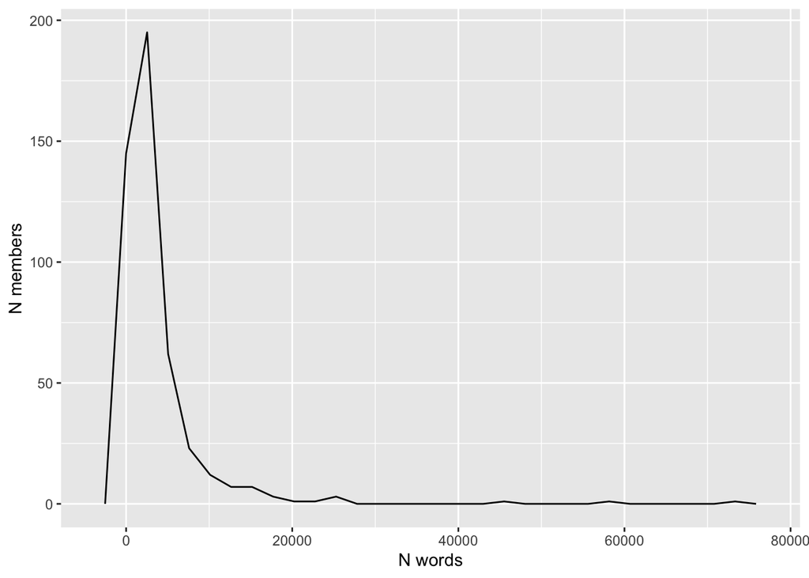

```r
counts.by.member <- dat %>%
         mutate(total = apply(word.dat, 1, sum)) %>%
         group_by(speaker) %>%
         summarize(total = sum(total))

ggplot(counts.by.member) +
  geom_freqpoly(mapping = aes(x = total)) +
  scale_x_continuous(name = "N words") +
  scale_y_continuous(name = "N members")
```

Another way to visualize this distribution is as a pie chart.

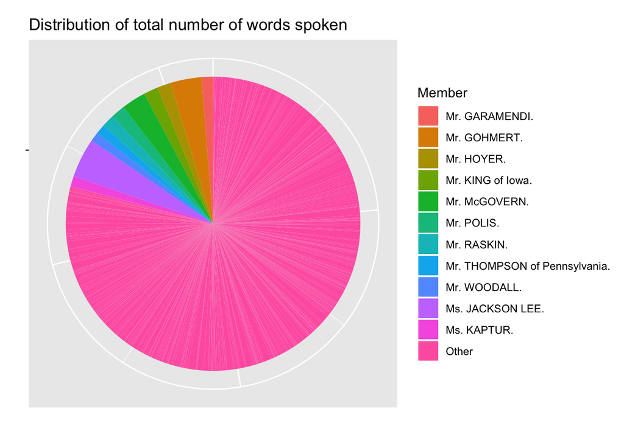

```r
# http://www.sthda.com/english/wiki/ggplot2-pie-chart-quick-start-guide-r-software-and-data-visualization
tmp <- counts.by.member %>% mutate(speaker = fct_lump(speaker, prop = .01, w = total))

ggplot(data = tmp,
       mapping = aes(x = "", y = total, fill = speaker)) +
  geom_bar(stat = "identity") +
  coord_polar("y") +
  ggtitle("Distribution of total number of words spoken") +
  scale_fill_discrete(name = "Member") +
  # https://stackoverflow.com/questions/35090883#35090981
  theme(axis.text.x = element_blank()) +
  # https://www.r-bloggers.com/pie-charts-in-ggplot2/
  xlab("") +
  ylab("")
```

Because I live in Pennsylvania, one name sticks out to me: Congressman Thompson from [Pennsylvania’s 15th district](https://en.wikipedia.org/wiki/Pennsylvania%27s_15th_congressional_district) (which borders Allegheny county). To see what he talked about the most, I generated a word cloud just on the words he used.

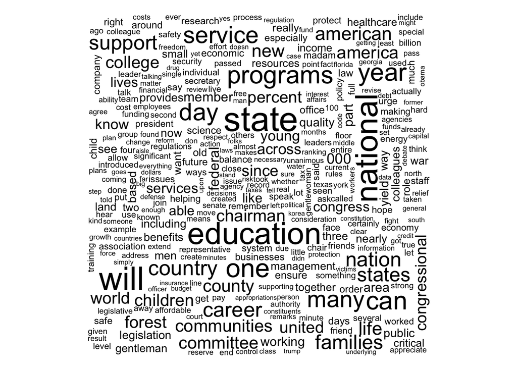

```r
thompson.dat <- dat %>%
  filter(speaker == "Mr. THOMPSON of Pennsylvania.") %>%
  select(-c("speaker","date","speech","party"))

word.counts <- apply(thompson.dat, 2, sum)

wordcloud(colnames(thompson.dat), word.counts)
```

[^1]: This is only counting words that were said more than 500 times, so it’s actually picking up on who says the most *commonly used* words.